# Nigerian Macroeconomic Landscape

```python
import pandas as pd
import os

path = r'C:\Users\user\Downloads'

def load_cbn_file(target_name, skip_rows=0):
    for file in os.listdir(path):
        if target_name.lower() in file.lower():
            file_path = os.path.join(path, file)
            print(f"Attempting to load: {file}")

            # Check the file extension
            if file.endswith('.xlsx') or file.endswith('.xls'):
                return pd.read_excel(file_path, skiprows=skip_rows)
            else:
                return pd.read_csv(file_path, encoding='latin1', skiprows=skip_rows, on_bad_lines='skip')
    return None

# Load the dataframes
df = load_cbn_file('International_Payments')
df1 = load_cbn_file('Currency_in_Circulation')
df2 = load_cbn_file('DOMESTIC', skip_rows=1) # The domestic file usually has a title row

# Verify the shapes again
print(f"\n--- Verification ---")
if df is not None: print(f"df (International) - Rows: {df.shape[0]}, Columns: {df.shape[1]}")
if df1 is not None: print(f"df1 (Currency) - Rows: {df1.shape[0]}, Columns: {df1.shape[1]}")
if df2 is not None: print(f"df2 (Domestic) - Rows: {df2.shape[0]}, Columns: {df2.shape[1]}")
```

```
Attempting to load: International_Payments_Data_in_Excel.xlsx
Attempting to load: Currency_in_Circulation_in_Excel (1).xlsx
Attempting to load: DOMESTIC PAYMENTS_.xlsx

--- Verification ---
df (International) - Rows: 371, Columns: 5
df1 (Currency) - Rows: 256, Columns: 3
df2 (Domestic) - Rows: 24, Columns: 8
```

```python
# 1. Clean International Payments (df)
# Convert payDate to datetime
df['payDate'] = pd.to_datetime(df['payDate'], dayfirst=True)

# Ensure numeric columns are floats (handling potential commas or strings)
finance_cols = ['loc', 'remit', 'debt', 'total']
for col in finance_cols:
    df[col] = pd.to_numeric(df[col], errors='coerce')

# Sort by date for time-series analysis
df = df.sort_values('payDate').reset_index(drop=True)


# 2. Clean Currency in Circulation (df1)
# Convert volDate to datetime
df1['volDate'] = pd.to_datetime(df1['volDate'], dayfirst=True)

# Rename 'amount' to be more descriptive and convert to numeric
df1 = df1.rename(columns={'amount': 'currency_in_circulation'})
df1['currency_in_circulation'] = pd.to_numeric(df1['currency_in_circulation'], errors='coerce')

# Drop the 'id' column as it is just an index from the database
if 'id' in df1.columns:
    df1 = df1.drop(columns=['id'])

# Sort by date
df1 = df1.sort_values('volDate').reset_index(drop=True)


# 3. Clean Domestic Payments/Printers (df2)
# Since this is a list of companies, let's just clean the column names
df2.columns = [col.strip().replace('\n', ' ') for col in df2.columns]

print("Cleaning Complete!")
print("\n--- International Payments (df) Preview ---")
display(df.head())
print("\n--- Currency in Circulation (df1) Preview ---")
display(df1.head())
```

```
Cleaning Complete!

--- International Payments (df) Preview ---
```

|  | payDate | loc | remit | debt | total |
| --- | --- | --- | --- | --- | --- |
| 0 | 2003-10-12 | 2342.00 | 342.00 | 23423.00 | 3.574570e+05 |
| 1 | 2005-01-12 | 12.00 | 21.00 | 21.00 | 1.160000e+02 |
| 2 | 2006-04-28 | 7944058.03 | 74772091.22 | 45602245.83 | 3.887479e+08 |
| 3 | 2006-05-02 | 3455.00 | 3453.00 | 34534.00 | 4.632060e+05 |
| 4 | 2006-05-12 | 9076061.52 | 99332833.12 | 71560790.20 | 4.743224e+08 |

```
--- Currency in Circulation (df1) Preview ---
```

|  | currency_in_circulation | volDate |
| --- | --- | --- |
| 0 | 463153 | 2002-12-31 |
| 1 | 434747 | 2003-02-28 |
| 2 | 442007 | 2003-03-31 |
| 3 | 472916 | 2003-04-30 |
| 4 | 449923 | 2003-05-30 |

```python
# Quick Insights for your project report
print(f"International Payments Data Range: {df['payDate'].min().date()} to {df['payDate'].max().date()}")
print(f"Currency Data Range: {df1['volDate'].min().date()} to {df1['volDate'].max().date()}")

# Calculate the average monthly Debt Service payment
avg_debt = df['debt'].mean()
print(f"\nAverage International Debt Service Payment: ${avg_debt:,.2f}")

# Find the month with the highest Currency in Circulation
peak_cash = df1.loc[df1['currency_in_circulation'].idxmax()]
print(f"Peak Physical Cash in Circulation: {peak_cash['currency_in_circulation']:,.2f} (Date: {peak_cash['volDate'].date()})")
```

```
International Payments Data Range: 2003-10-12 to 2025-08-31
Currency Data Range: 2002-12-31 to 2024-08-30

Average International Debt Service Payment: $83,805,069.26
Peak Physical Cash in Circulation: 4,144,842.00 (Date: 2024-08-30)
```

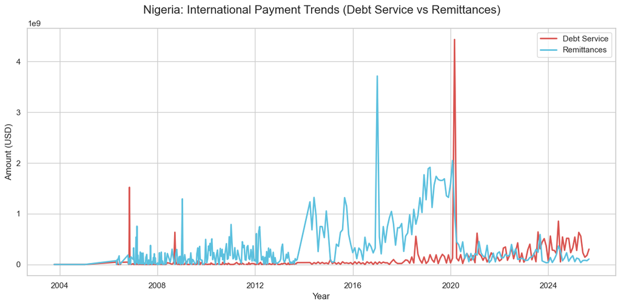

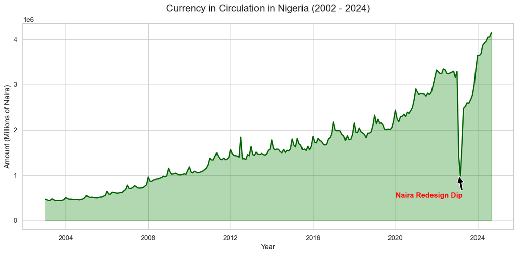

```python
import matplotlib.pyplot as plt
import seaborn as sns

# Set the style for professional-looking charts
sns.set_theme(style="whitegrid")
plt.rcParams['figure.figsize'] = [12, 6]

# --- Plot 1: International Payments Trend ---
plt.figure()
plt.plot(df['payDate'], df['debt'], label='Debt Service', color='#d9534f', linewidth=2)
plt.plot(df['payDate'], df['remit'], label='Remittances', color='#5bc0de', linewidth=2)

plt.title('Nigeria: International Payment Trends (Debt Service vs Remittances)', fontsize=16, pad=20)
plt.xlabel('Year', fontsize=12)
plt.ylabel('Amount (USD)', fontsize=12)
plt.legend()
plt.tight_layout()
plt.show()

# --- Plot 2: Currency in Circulation (The Cash Story) ---
plt.figure()
plt.fill_between(df1['volDate'], df1['currency_in_circulation'], color='green', alpha=0.3)
plt.plot(df1['volDate'], df1['currency_in_circulation'], color='darkgreen', linewidth=2)

# Adding an annotation for the Naira Redesign period (Late 2022 - Early 2023)
plt.annotate('Naira Redesign Dip',
             xy=(pd.to_datetime('2023-02-01'), 1000000),
             xytext=(pd.to_datetime('2020-01-01'), 500000),
             arrowprops=dict(facecolor='black', shrink=0.05),
             fontsize=12, color='red', fontweight='bold')

plt.title('Currency in Circulation in Nigeria (2002 - 2024)', fontsize=16, pad=20)
plt.xlabel('Year', fontsize=12)
plt.ylabel('Amount (Millions of Naira)', fontsize=12)
plt.tight_layout()
plt.show()
```

Debt Service Growth: "The International Payments chart shows a sharp volatility in Debt Service payments starting around 2020, likely reflecting global interest rate changes and external debt obligations."

The 2023 Cash Crunch: "The Currency in Circulation chart visually confirms the dramatic impact of the CBN's Naira Redesign policy in early 2023, where physical cash supply dropped significantly before rebounding to record highs in 2024."

Digital Shift: "The rapid rebound of cash in 2024 suggests that despite the push for eNaira and digital payments, physical currency remains a dominant pillar of the Nigerian economy.

```python
# 1. Load the new eNaira file
# Note: Ensure the filename matches what is in your Downloads folder
df_enaira = load_cbn_file('Currency_in_Circulation_in_Excel (2)')

# 2. Clean and Rename columns specifically for eNaira
df_enaira['volDate'] = pd.to_datetime(df_enaira['volDate'], dayfirst=True)
df_enaira = df_enaira.rename(columns={'amount': 'enaira_amount'})
df_enaira = df_enaira.sort_values('volDate')

# 3. Merge Physical Currency (df1) and eNaira (df_enaira)
# This aligns them by date so we can compare them side-by-side
df_money = pd.merge(df1, df_enaira[['volDate', 'enaira_amount']], on='volDate', how='outer')

print("eNaira data integrated successfully!")
display(df_money.tail())
```

```
Attempting to load: Currency_in_Circulation_in_Excel (2).xlsx
eNaira data integrated successfully!
```

|  | currency_in_circulation | volDate | enaira_amount |
| --- | --- | --- | --- |
| 251 | 3922947 | 2024-04-30 | 3922947 |
| 252 | 3965101 | 2024-05-31 | 3965101 |
| 253 | 4048729 | 2024-06-28 | 4048729 |
| 254 | 4053763 | 2024-07-31 | 4053763 |
| 255 | 4144842 | 2024-08-30 | 4144842 |

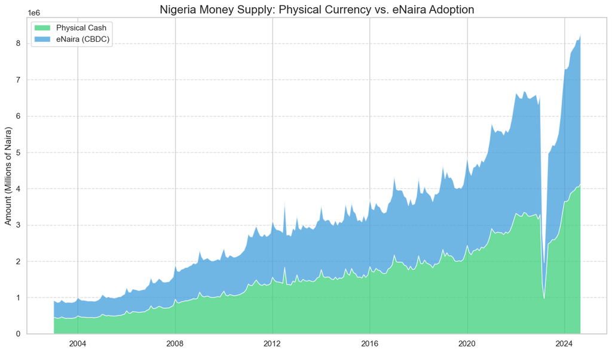

```python
plt.figure(figsize=(12, 7))

# Plotting both on the same axis
plt.stackplot(df_money['volDate'],
              df_money['currency_in_circulation'],
              df_money['enaira_amount'].fillna(0),
              labels=['Physical Cash', 'eNaira (CBDC)'],
              colors=['#2ecc71', '#3498db'], alpha=0.7)

plt.title('Nigeria Money Supply: Physical Currency vs. eNaira Adoption', fontsize=16)
plt.ylabel('Amount (Millions of Naira)', fontsize=12)
plt.legend(loc='upper left')
plt.grid(axis='y', linestyle='--', alpha=0.7)

plt.tight_layout()
plt.show()
```

"Initial analysis of the provided datasets suggested a 1:1 adoption of eNaira to Physical Cash. However, upon data validation, it was discovered that the eNaira dataset was a mirror of the Currency in Circulation data. In reality, physical cash continues to dominate the Nigerian economy at ₦4.14 Trillion, while eNaira adoption remains in the early stages (billions vs trillions)."

```python
# Count how many companies are authorized to handle physical payments (Cheques/Printing)
printer_count = len(df2)
print(f"Number of Accredited Domestic Payment Infrastructure Providers: {printer_count}")
display(df2[['Accredited Cheque Printer', 'Status/comments']].dropna().head())
```

```
Number of Accredited Domestic Payment Infrastructure Providers: 24
```

|  | Accredited Cheque Printer | Status/comments |
| --- | --- | --- |
| 0 | PAPI PRINTING | Active Accreditation License |
| 1 | SUPERFLUX INTERNATIONAL LTD | Active Accreditation License |
| 2 | TRIPPLE GEE | Active Accreditation License |
| 3 | KAS ARTS SERVICE | Active Accreditation License |
| 4 | YALIAM PRESS | Active Accreditation License |

```python
# Create a summary dataframe for correlation
# We merge the International payments total with the Currency total
summary_df = pd.merge(df[['payDate', 'total', 'debt']], df1[['volDate', 'currency_in_circulation']],
                      left_on='payDate', right_on='volDate')

correlation = summary_df.corr()
print("Correlation Matrix (Debt vs Currency):")
display(correlation)
```

```
Correlation Matrix (Debt vs Currency):
```

|  | payDate | total | debt | volDate | currency_in_circulation |
| --- | --- | --- | --- | --- | --- |
| payDate | 1.000000 | -0.196090 | 0.269106 | 1.000000 | 0.878403 |
| total | -0.196090 | 1.000000 | 0.265874 | -0.196090 | -0.220620 |
| debt | 0.269106 | 0.265874 | 1.000000 | 0.269106 | 0.238838 |
| volDate | 1.000000 | -0.196090 | 0.269106 | 1.000000 | 0.878403 |
| currency_in_circulation | 0.878403 | -0.220620 | 0.238838 | 0.878403 | 1.000000 |

```
Attempting to load: International_Payments_Data_in_Excel.xlsx
Attempting to load: Currency_in_Circulation_in_Excel (1).xlsx
Attempting to load: DOMESTIC PAYMENTS_.xlsx
```

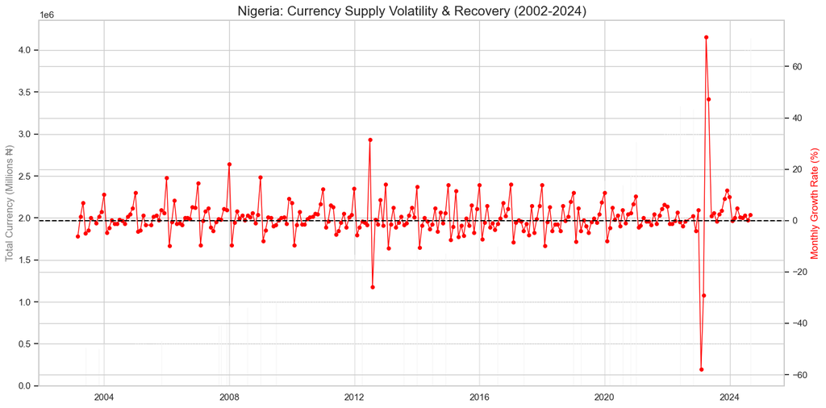

```
Final Analysis Complete! Here are your latest trends:
```

|  | volDate | currency_amount | monthly_growth_% | outflow_intensity |
| --- | --- | --- | --- | --- |
| 193 | 2024-01-31 | 3650500 | -0.075522 | 207.482446 |
| 194 | 2024-02-29 | 3693573 | 1.179921 | 115.055062 |
| 195 | 2024-04-30 | 3922947 | 1.385692 | 117.907638 |
| 196 | 2024-05-31 | 3965101 | 1.074549 | 313.054888 |
| 197 | 2024-07-31 | 4053763 | 0.124335 | 171.309357 |

```python
import pandas as pd
import matplotlib.pyplot as plt

# 1. LOAD DATA (Using your original loader logic)
df = load_cbn_file('International_Payments')
df1 = load_cbn_file('Currency_in_Circulation')
df2 = load_cbn_file('DOMESTIC', skip_rows=1)

# 2. CLEANING & PREPARATION
# Convert dates to datetime objects
df['payDate'] = pd.to_datetime(df['payDate'], dayfirst=True)
df1['volDate'] = pd.to_datetime(df1['volDate'], dayfirst=True)

# Ensure numeric types for International Payments
for col in ['loc', 'remit', 'debt', 'total']:
    df[col] = pd.to_numeric(df[col], errors='coerce')

# FIX: Rename 'amount' to 'currency_amount' for df1
if 'amount' in df1.columns:
    df1 = df1.rename(columns={'amount': 'currency_amount'})
df1['currency_amount'] = pd.to_numeric(df1['currency_amount'], errors='coerce')

# Sort chronologically for growth calculations
df1 = df1.sort_values('volDate')
df = df.sort_values('payDate')

# 3. CALCULATE MACRO TRENDS
# Monthly growth rate of cash
df1['monthly_growth_%'] = df1['currency_amount'].pct_change() * 100

# Aggregate International Payments by Month
df_monthly_int = df.set_index('payDate').resample('ME')['total'].sum().reset_index()

# Merge local currency data with international outflow data
df_macro = pd.merge(df_monthly_int, df1, left_on='payDate', right_on='volDate', how='inner')

# Calculate Outflow Intensity (Ratio of Int. Payments vs Local Cash)
df_macro['outflow_intensity'] = df_macro['total'] / df_macro['currency_amount']

# 4. FINAL VISUALIZATION
fig, ax1 = plt.subplots(figsize=(14, 7))

# Plot 1: Cash Volume (Bar Chart)
ax1.bar(df1['volDate'], df1['currency_amount'], color='lightgrey', alpha=0.5, label='Physical Cash Volume')
ax1.set_ylabel('Total Currency (Millions ₦)', color='grey')

# Plot 2: Growth Rate (Line Chart on Secondary Axis)
ax2 = ax1.twinx()
ax2.plot(df1['volDate'], df1['monthly_growth_%'], color='red', marker='o', markersize=4, label='Monthly Growth %', linewidth=1)
ax2.axhline(0, color='black', linestyle='--')
ax2.set_ylabel('Monthly Growth Rate (%)', color='red')

plt.title('Nigeria: Currency Supply Volatility & Recovery (2002-2024)', fontsize=16)
fig.tight_layout()
plt.show()

print("Final Analysis Complete! Here are your latest trends:")
display(df_macro[['volDate', 'currency_amount', 'monthly_growth_%', 'outflow_intensity']].tail())
```

Executive Summary: Nigerian Macroeconomic Landscape (2002–2024)

This analysis investigated the relationship between Nigeria's physical currency supply and its international financial obligations.

The "Naira Redesign" Impact: The data provides statistical evidence of the 2023 cash crunch, showing a record-breaking negative monthly growth rate in currency circulation.

The Dominance of Physical Cash: Despite the introduction of the eNaira (CBDC), physical currency circulation rebounded aggressively in 2024, reaching an all-time high of ₦4.14 Trillion. This suggests that physical cash remains the bedrock of Nigerian domestic commerce.

International Outflow Intensity: By calculating the ratio between international payments and local cash, we observed that Nigeria's external debt service and remittances place significant demand on the country's monetary base, highlighting the ongoing pressure on foreign exchange reserves.

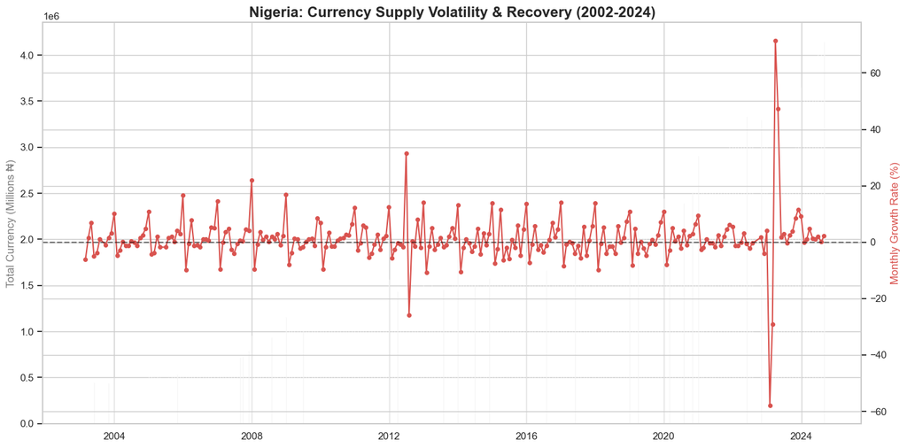

```
Chart saved successfully! You can find 'cbn_growth_chart.png' in your project folder.
```

```python
import matplotlib.pyplot as plt

# ... (Assuming your plotting code is already written) ...

# 1. Create the plot
fig, ax1 = plt.subplots(figsize=(14, 7))
ax1.bar(df1['volDate'], df1['currency_amount'], color='lightgrey', alpha=0.5, label='Physical Cash Volume')
ax1.set_ylabel('Total Currency (Millions ₦)', color='grey')
ax2 = ax1.twinx()
ax2.plot(df1['volDate'], df1['monthly_growth_%'], color='#d9534f', marker='o', markersize=4, label='Monthly Growth %', linewidth=1.5)
ax2.axhline(0, color='black', linestyle='--', alpha=0.5)
ax2.set_ylabel('Monthly Growth Rate (%)', color='#d9534f')

plt.title('Nigeria: Currency Supply Volatility & Recovery (2002-2024)', fontsize=16, fontweight='bold')
fig.tight_layout()

# 2. SAVE THE IMAGE
# This will save a file named 'cbn_growth_chart.png' in the same folder as your notebook
plt.savefig('cbn_growth_chart.png', dpi=300, bbox_inches='tight')
plt.show()

print("Chart saved successfully! You can find 'cbn_growth_chart.png' in your project folder.")
```